# PCA

**Dimension Reduction Techniques (PCA)**

## Problem Statement:

A key challenge for property sellers is to determine the sale price of the property. The ability to predict the exact property value is beneficial for property investors as well as for buyers to plan their finances according to the price trend. The property prices depend on the number of features like the property area, basement square footage, year built, number of bedrooms, and others. The prices can be predicted more accurately if the number of predictors is less. Several dimension reduction techniques are being applied to decrease this number of predictors.

## Data Definition:

Input variables:

**1.MSSubClass:** Identifies the type of dwelling involved in the sale

```
    20  1-STORY 1946 & NEWER ALL STYLES
    30  1-STORY 1945 & OLDER
    40  1-STORY W/FINISHED ATTIC ALL AGES
    45  1-1/2 STORY - UNFINISHED ALL AGES
    50  1-1/2 STORY FINISHED ALL AGES
    60  2-STORY 1946 & NEWER
    70  2-STORY 1945 & OLDER
    75  2-1/2 STORY ALL AGES
    80  SPLIT OR MULTI-LEVEL
    85  SPLIT FOYER
    90  DUPLEX - ALL STYLES AND AGES
   120  1-STORY PUD (Planned Unit Development) - 1946 & NEWER
   150  1-1/2 STORY PUD - ALL AGES
   160  2-STORY PUD - 1946 & NEWER
   180  PUD - MULTILEVEL - INCL SPLIT LEV/FOYER
   190  2 FAMILY CONVERSION - ALL STYLES AND AGES
```

**2.MSZoning:** Identifies the general zoning classification of the sale

```
   A     Agriculture
   C     Commercial
   FV   Floating Village Residential
   I     Industrial
   RH   Residential High Density
   RL   Residential Low Density
   RP   Residential Low Density Park
   RM   Residential Medium Density
```

**3.LotFrontage:** Linear feet of street connected to property

**4.LotArea:** Lot size is the lot or parcel side where it adjoins a street, boulevard or access way

**5.Street:** Type of road access to property

```
   Grvl Gravel
   Pave Paved
```

**6.Alley:** Type of alley access to property

```
   Grvl Gravel
   Pave Paved
   NA    No alley access
```

**7.LotShape:** General shape of property

```
   Reg  Regular
   IR1  Slightly irregular
   IR2  Moderately Irregular
   IR3  Irregular
```

**8.LandContour:** Flatness of the property

```
   Lvl  Near Flat/Level
   Bnk  Banked - Quick and significant rise from street grade to building
   HLS  Hillside - Significant slope from side to side
   Low  Depression
```

**9.Utilities:** Type of utilities available

```
   AllPub   All public Utilities (E,G,W,& S)
   NoSewr   Electricity, Gas, and Water (Septic Tank)
   NoSeWa   Electricity and Gas Only
   ELO     Electricity only
```

**10.LotConfig:** Lot configuration

```
   Inside   Inside lot
   Corner   Corner lot
   CulDSac   Cul-de-sac
   FR2     Frontage on 2 sides of property
   FR3     Frontage on 3 sides of property
```

**11.LandSlope:** Slope of property

```
   Gtl  Gentle slope
   Mod  Moderate Slope
   Sev  Severe Slope
```

**12.Neighborhood:** Physical locations within Ames city limits

```
   Blmngtn  Bloomington Heights
   Blueste  Bluestem
   BrDale    Briardale
   BrkSide  Brookside
   ClearCr  Clear Creek
   CollgCr  College Creek
   Crawfor  Crawford
   Edwards  Edwards
   Gilbert  Gilbert
   IDOTRR    Iowa DOT and Rail Road
   MeadowV  Meadow Village
   Mitchel  Mitchell
   Names      North Ames
   NoRidge  Northridge
   NPkVill  Northpark Villa
   NridgHt  Northridge Heights
   NWAmes    Northwest Ames
   OldTown  Old Town
   SWISU      South & West of Iowa State University
   Sawyer    Sawyer
   SawyerW  Sawyer West
   Somerst  Somerset
   StoneBr  Stone Brook
   Timber    Timberland
   Veenker  Veenker
```

**13.Condition1:** Proximity to various conditions

```
   Artery  Adjacent to arterial street
   Feedr   Adjacent to feeder street
   Norm Normal
   RRNn Within 200' of North-South Railroad
   RRAn Adjacent to North-South Railroad
   PosN Near positive off-site feature--park, greenbelt, etc.
   PosA Adjacent to postive off-site feature
   RRNe Within 200' of East-West Railroad
   RRAe Adjacent to East-West Railroad
```

**14.Condition2:** Proximity to various conditions (if more than one is present)

```
   Artery      Adjacent to arterial street
   Feedr       Adjacent to feeder street
   Norm     Normal
   RRNn     Within 200' of North-South Railroad
   RRAn     Adjacent to North-South Railroad
   PosN     Near positive off-site feature--park, greenbelt, etc.
   PosA     Adjacent to postive off-site feature
   RRNe     Within 200' of East-West Railroad
   RRAe     Adjacent to East-West Railroad
```

**15.BldgType:** Type of dwelling

```
   1Fam   Single-family Detached
   2FmCon   Two-family Conversion; originally built as one-family dwelling
   Duplx     Duplex
   TwnhsE   Townhouse End Unit
   TwnhsI   Townhouse Inside Unit
```

**16.HouseStyle:** Style of dwelling

```
   1Story   One story
   1.5Fin   One and one-half story: 2nd level finished
   1.5Unf   One and one-half story: 2nd level unfinished
   2Story   Two story
   2.5Fin   Two and one-half story: 2nd level finished
   2.5Unf   Two and one-half story: 2nd level unfinished
   SFoyer   Split Foyer
   SLvl   Split Level
```

**17.OverallQual:** Rates the overall material and finish of the house

```
   10   Very Excellent
   9    Excellent
   8    Very Good
   7    Good
   6    Above Average
   5    Average
   4    Below Average
   3    Fair
   2    Poor
   1    Very Poor
```

**18.OverallCond:** Rates the overall condition of the house

```
   10   Very Excellent
   9    Excellent
   8    Very Good
   7    Good
   6    Above Average
   5    Average
   4    Below Average
   3    Fair
   2    Poor
   1    Very Poor
```

**19.YearBuilt:** Original construction date

**20.YearRemodAdd:** Remodel date (same as construction date if no remodeling or additions)

**21.RoofStyle:** Type of roof

```
   Flat    Flat
   Gable      Gable
   Gambrel  Gabrel (Barn)
   Hip      Hip
   Mansard  Mansard
   Shed    Shed
```

**22.RoofMatl:** Roof material

```
   ClyTile  Clay or Tile
   CompShg  Standard (Composite) Shingle
   Membran  Membrane
   Metal      Metal
   Roll    Roll
   Tar&Grv  Gravel & Tar
   WdShake  Wood Shakes
   WdShngl  Wood Shingles
```

**23.Exterior1st:** Exterior covering on house

```
   AsbShng  Asbestos Shingles
   AsphShn  Asphalt Shingles
   BrkComm  Brick Common
   BrkFace  Brick Face
   CBlock    Cinder Block
   CemntBd  Cement Board
   HdBoard  Hard Board
   ImStucc  Imitation Stucco
   MetalSd  Metal Siding
   Other      Other
   Plywood  Plywood
   PreCast  PreCast
   Stone      Stone
   Stucco    Stucco
   VinylSd  Vinyl Siding
   Wd Sdng  Wood Siding
   WdShing  Wood Shingles
```

**24.Exterior2nd:** Exterior covering on house (if more than one material)

```
   AsbShng  Asbestos Shingles
   AsphShn  Asphalt Shingles
   BrkComm  Brick Common
   BrkFace  Brick Face
   CBlock    Cinder Block
   CemntBd  Cement Board
   HdBoard  Hard Board
   ImStucc  Imitation Stucco
   MetalSd  Metal Siding
   Other      Other
   Plywood  Plywood
   PreCast  PreCast
   Stone      Stone
   Stucco     Stucco
   VinylSd  Vinyl Siding
   Wd Sdng  Wood Siding
   WdShing  Wood Shingles
```

**25.MasVnrType:** Masonry veneer type

```
   BrkCmn     Brick Common
   BrkFace  Brick Face
   CBlock    Cinder Block
   None    None
   Stone      Stone
```

**26.MasVnrArea:** Masonry veneer area in square feet

**27.ExterQual:** Evaluates the quality of the material on the exterior

```
   Ex   Excellent
   Gd   Good
   TA   Average/Typical
   Fa   Fair
   Po   Poor
```

**28.ExterCond:** Evaluates the present condition of the material on the exterior

```
   Ex   Excellent
   Gd   Good
   TA   Average/Typical
   Fa   Fair
   Po   Poor
```

**29.Foundation:** Type of foundation

```
   BrkTil   Brick & Tile
   CBlock   Cinder Block
   PConc     Poured Contrete
   Slab   Slab
   Stone     Stone
   Wood   Wood
```

**30.BsmtQual:** Evaluates the height of the basement

```
   Ex   Excellent (100+ inches)
   Gd   Good (90-99 inches)
   TA   Typical (80-89 inches)
   Fa   Fair (70-79 inches)
   Po   Poor (<70 inches
   NA   No Basement
```

**31.BsmtCond:** Evaluates the general condition of the basement

```
   Ex   Excellent
   Gd   Good
   TA   Typical - slight dampness allowed
   Fa   Fair - dampness or some cracking or settling
   Po   Poor - Severe cracking, settling, or wetness
   NA   No Basement
```

**32.BsmtExposure:** Refers to walkout or garden level walls

```
   Gd   Good Exposure
   Av   Average Exposure (split levels or foyers typically score average or above)
   Mn   Mimimum Exposure
   No   No Exposure
   NA   No Basement
```

**33.BsmtFinType1:** Rating of basement finished area

```
   GLQ  Good Living Quarters
   ALQ  Average Living Quarters
   BLQ  Below Average Living Quarters
   Rec  Average Rec Room
   LwQ  Low Quality
   Unf  Unfinshed
   NA    No Basement
```

**34.BsmtFinSF1:** Type 1 finished square feet

**35.BsmtFinType2:** Rating of basement finished area (if multiple types)

```
   GLQ  Good Living Quarters
   ALQ  Average Living Quarters
   BLQ  Below Average Living Quarters
   Rec  Average Rec Room
   LwQ  Low Quality
   Unf  Unfinshed
   NA    No Basement
```

**36.BsmtFinSF2:** Type 2 finished square feet

**37.BsmtUnfSF:** Unfinished square feet of basement area

**38.TotalBsmtSF:** Total square feet of basement area

**39.Heating:** Type of heating

```
   Floor   Floor Furnace
   GasA Gas forced warm air furnace
   GasW Gas hot water or steam heat
   Grav Gravity furnace
   OthW Hot water or steam heat other than gas
   Wall Wall furnace
```

**40.HeatingQC:** Heating quality and condition

```
   Ex   Excellent
   Gd   Good
   TA   Average/Typical
   Fa   Fair
   Po   Poor
```

**41.CentralAir:** Central air conditioning

```
   N    No
   Y    Yes
```

**42.Electrical:** Electrical system

```
   SBrkr    Standard Circuit Breakers & Romex
   FuseA    Fuse Box over 60 AMP and all Romex wiring (Average)
   FuseF    60 AMP Fuse Box and mostly Romex wiring (Fair)
   FuseP    60 AMP Fuse Box and mostly knob & tube wiring (poor)
   Mix    Mixed
```

**43.1stFlrSF:** First Floor square feet

**44.2ndFlrSF:** Second floor square feet

**45.LowQualFinSF:** Low quality finished square feet (all floors)

**46.GrLivArea:** Above grade (ground) living area square feet

**47.BsmtFullBath:** Basement full bathrooms

**48.BsmtHalfBath:** Basement half bathrooms

**49.FullBath:** Full bathrooms above grade

**50.HalfBath:** Half baths above grade

**51.BedroomAbvGr:** Bedrooms above grade (does NOT include basement bedrooms)

**52.KitchenAbvGr:** Kitchens above grade

**53.KitchenQual:** Kitchen quality

```
   Ex   Excellent
   Gd   Good
   TA   Typical/Average
   Fa   Fair
   Po   Poor
```

**54.TotRmsAbvGrd:** Total rooms above grade (does not include bathrooms)

**55.Functional:** Home functionality (Assume typical unless deductions are warranted)

```
   Typ  Typical Functionality
   Min1   Minor Deductions 1
   Min2   Minor Deductions 2
   Mod  Moderate Deductions
   Maj1   Major Deductions 1
   Maj2   Major Deductions 2
   Sev  Severely Damaged
   Sal  Salvage only
```

**56.Fireplaces:** Number of fireplaces

**57.FireplaceQu:** Fireplace quality

```
   Ex   Excellent - Exceptional Masonry Fireplace
   Gd   Good - Masonry Fireplace in main level
   TA   Average - Prefabricated Fireplace in main living area or Masonry Fireplace in basement
   Fa   Fair - Prefabricated Fireplace in basement
   Po   Poor - Ben Franklin Stove
   NA   No Fireplace
```

**58.GarageType:** Garage location

```
   2Types   More than one type of garage
   Attchd   Attached to home
   Basment   Basement Garage
   BuiltIn   Built-In (Garage part of house - typically has room above garage)
   CarPort   Car Port
   Detchd   Detached from home
   NA       No Garage
```

**59.GarageYrBlt:** Year garage was built

**60.GarageFinish:** Interior finish of the garage

```
   Fin  Finished
   RFn  Rough Finished
   Unf  Unfinished
   NA    No Garage
```

**61.GarageCars:** Size of garage in car capacity

**62.GarageArea:** Size of garage in square feet

**63.GarageQual:** Garage quality

```
   Ex   Excellent
   Gd   Good
   TA   Typical/Average
   Fa   Fair
   Po   Poor
   NA   No Garage
```

**64.GarageCond:** Garage condition

```
   Ex   Excellent
   Gd   Good
   TA   Typical/Average
   Fa   Fair
   Po   Poor
   NA   No Garage
```

**65.PavedDrive:** Paved driveway

```
   Y    Paved
   P    Partial Pavement
   N    Dirt/Gravel
```

**66.WoodDeckSF:** Wood deck area in square feet

**67.OpenPorchSF:** Open porch area in square feet

**68.EnclosedPorch:** Enclosed porch area in square feet

**69.3SsnPorch:** Three season porch area in square feet

**70.ScreenPorch:** Screen porch area in square feet

**71.PoolArea:** Pool area in square feet

**72.PoolQC:** Pool quality

```
   Ex   Excellent
   Gd   Good
   TA   Average/Typical
   Fa   Fair
   NA   No Pool
```

**73.Fence:** Fence quality

```
   GdPrv    Good Privacy
   MnPrv    Minimum Privacy
   GdWo  Good Wood
   MnWw  Minimum Wood/Wire
   NA      No Fence
```

**74.MiscFeature:** Miscellaneous feature not covered in other categories

```
   Elev Elevator
   Gar2 2nd Garage (if not described in garage section)
   Othr Other
   Shed Shed (over 100 SF)
   TenC Tennis Court
   NA     None
```

**75.MiscVal:** Value of miscellaneous feature

**76.MoSold:** Month Sold (MM)

**77.YrSold:** Year Sold (YYYY)

**78.SaleType: Type of sale**

```
   WD   Warranty Deed - Conventional
   CWD  Warranty Deed - Cash
   VWD  Warranty Deed - VA Loan
   New  Home just constructed and sold
   COD  Court Officer Deed/Estate
   Con  Contract 15% Down payment regular terms
   ConLw  Contract Low Down payment and low interest
   ConLI  Contract Low Interest
   ConLD  Contract Low Down
   Oth  Other
```

**79.SaleCondition:** Condition of sale

```
   Normal   Normal Sale
   Abnorml   Abnormal Sale -  trade, foreclosure, short sale
   AdjLand   Adjoining Land Purchase
   Alloca    Allocation - two linked properties with separate deeds, typically condo with a garage unit
   Family   Sale between family members
   Partial   Home was not completed when last assessed (associated with New Homes)
```

## Content

1. **Import Packages**
2. **Read Data**
3. **Understand and Prepare the Data**
   - 3.1 - Data Types and Dimensions
   - 3.2 - Feature Engineering
   - 3.3 - Missing Data Treatment
4. **Compute Principal Component (from scratch)**
   - 4.1 - Prepare the Data
   - 4.2 - Scale the Data
   - 4.3 - Covariance Matrix
   - 4.4 - Compute Eigenvalues and Eigenvectors
   - 4.5 - Decide Number of Principal Components
   - 4.6 - Calculate Principal Components
5. **Compute Principal Component (using sklearn)**
6. **Conclusion**

## 1. Import Packages

```python
# 'Pandas' is used for data manipulation and analysis
import pandas as pd

# 'Numpy' is used for mathematical operations on large, multi-dimensional arrays and matrices
import numpy as np

# 'Matplotlib' is a data visualization library for 2D and 3D plots, built on numpy
import matplotlib.pyplot as plt

# 'datetime' is used to perform date and time operations
import datetime as dt

# 'StandardScalar' from sklearn.preprocessing library is used to scale the data
from sklearn.preprocessing import StandardScaler

# 'eig' from numpy.linalg to calculate eigenvalues and eigenvectors
from numpy.linalg import eig

# 'PCA' function to perform principal component analysis using the sklearn library
from sklearn.decomposition import PCA
```

## 2. Read the Data

|  | **Read the data using read_csv() function from pandas** |
| --- | --- |

```python
# read the data
raw_data = pd.read_csv('houseprice.csv')
# print the first five rows of the data
raw_data.head()
```

|  | Id | MSSubClass | MSZoning | LotFrontage | LotArea | Street | Alley | LotShape | LandContour | Utilities | ... | PoolArea | PoolQC | Fence | MiscFeature | MiscVal | MoSold | YrSold | SaleType | SaleCondition | SalePrice |
| --- | --- | --- | --- | --- | --- | --- | --- | --- | --- | --- | --- | --- | --- | --- | --- | --- | --- | --- | --- | --- | --- |
| 0 | 1 | 60 | RL | 65.0 | 8450 | Pave | NaN | Reg | Lvl | AllPub | ... | 0 | NaN | NaN | NaN | 0 | 2 | 2008 | WD | Normal | 208500 |
| 1 | 2 | 20 | RL | 80.0 | 9600 | Pave | NaN | Reg | Lvl | AllPub | ... | 0 | NaN | NaN | NaN | 0 | 5 | 2007 | WD | Normal | 181500 |
| 2 | 3 | 60 | RL | 68.0 | 11250 | Pave | NaN | IR1 | Lvl | AllPub | ... | 0 | NaN | NaN | NaN | 0 | 9 | 2008 | WD | Normal | 223500 |
| 3 | 4 | 70 | RL | 60.0 | 9550 | Pave | NaN | IR1 | Lvl | AllPub | ... | 0 | NaN | NaN | NaN | 0 | 2 | 2006 | WD | Abnorml | 140000 |
| 4 | 5 | 60 | RL | 84.0 | 14260 | Pave | NaN | IR1 | Lvl | AllPub | ... | 0 | NaN | NaN | NaN | 0 | 12 | 2008 | WD | Normal | 250000 |

5 rows × 81 columns

## 3. Understand and Prepare the Data

[figure not shown]

The process of data preparation entails cleansing, structuring and integrating data to make it ready for analysis.  
Here we will analyze and prepare data to perform regression techniques:  
1. Check dimensions and data types of the dataframe  
2. Study summary statistics  
3. Check for missing values  
4. Study correlation

#### Change index column

The first column in the data contains a unique numbering for each observation. We can make this column as an index column

```python
# the parameter 'index_col' will change the index to the specified column
raw_data = pd.read_csv('houseprice.csv', index_col=0)

# head() to display top five rows
raw_data.head()
```

| Id | MSSubClass | MSZoning | LotFrontage | LotArea | Street | Alley | LotShape | LandContour | Utilities | LotConfig | ... | PoolArea | PoolQC | Fence | MiscFeature | MiscVal | MoSold | YrSold | SaleType | SaleCondition | SalePrice |
| --- | --- | --- | --- | --- | --- | --- | --- | --- | --- | --- | --- | --- | --- | --- | --- | --- | --- | --- | --- | --- | --- |
| 1 | 60 | RL | 65.0 | 8450 | Pave | NaN | Reg | Lvl | AllPub | Inside | ... | 0 | NaN | NaN | NaN | 0 | 2 | 2008 | WD | Normal | 208500 |
| 2 | 20 | RL | 80.0 | 9600 | Pave | NaN | Reg | Lvl | AllPub | FR2 | ... | 0 | NaN | NaN | NaN | 0 | 5 | 2007 | WD | Normal | 181500 |
| 3 | 60 | RL | 68.0 | 11250 | Pave | NaN | IR1 | Lvl | AllPub | Inside | ... | 0 | NaN | NaN | NaN | 0 | 9 | 2008 | WD | Normal | 223500 |
| 4 | 70 | RL | 60.0 | 9550 | Pave | NaN | IR1 | Lvl | AllPub | Corner | ... | 0 | NaN | NaN | NaN | 0 | 2 | 2006 | WD | Abnorml | 140000 |
| 5 | 60 | RL | 84.0 | 14260 | Pave | NaN | IR1 | Lvl | AllPub | FR2 | ... | 0 | NaN | NaN | NaN | 0 | 12 | 2008 | WD | Normal | 250000 |

5 rows × 80 columns

## 3.1 Data Types and Dimensions

```python
# check the data types for variables
raw_data.info()
```

```
<class 'pandas.core.frame.DataFrame'>
Int64Index: 1460 entries, 1 to 1460
Data columns (total 80 columns):
 #   Column         Non-Null Count  Dtype
---  ------         --------------  -----
 0   MSSubClass     1460 non-null   int64
 1   MSZoning       1460 non-null   object
 2   LotFrontage    1201 non-null   float64
 3   LotArea        1460 non-null   int64
 4   Street         1460 non-null   object
 5   Alley          91 non-null     object
 6   LotShape       1460 non-null   object
 7   LandContour    1460 non-null   object
 8   Utilities      1460 non-null   object
 9   LotConfig      1460 non-null   object
```

[output cut: 72 more lines]

[output not shown]

```python
# get the shape
print(raw_data.shape)
```

```
(1460, 80)
```

**We see the dataframe has 80 columns and 1460 observations**

[figure not shown]

From the above output, we see that the data type of the variables like 'MSSubclass', 'OverallQual', 'OverallCond' has 'int64' data type  
But by data definition these are 'categorical' variables. So we will convert the data type of these variables to object

```python
# Use .astype() to change the data type
# use 'for' loop to change the data type of a large number of columns
for feature in ['MSSubClass','OverallQual','OverallCond']:
    raw_data[feature] = raw_data[feature].astype('object')
```

**Let us now recheck the data type once again after we have done the conversion in the immediate last step**

```python
# recheck of the data type
raw_data.dtypes
```

```
MSSubClass        object
MSZoning          object
LotFrontage      float64
LotArea            int64
Street            object
                  ...
MoSold             int64
YrSold             int64
SaleType          object
SaleCondition     object
SalePrice          int64
Length: 80, dtype: object
```

## 3.2 Feature Engineering

[figure not shown]

**Features like 'YearBuilt' and 'YearRemodAdd' represent the initial construction year and year of remodeling respectively. Create new columns namely, 'Buiding_age' and 'Remodel_age' that provide the information about the age of building and years since remodeled**

```python
# 'now().year' gives the current year
# store the year as 'current_year'
current_year = int(dt.datetime.now().year)
```

```python
# creating 2 new columns as 'Buiding_age' and 'Remoel_age'
Buiding_age = current_year - raw_data.YearBuilt
Remodel_age = current_year - raw_data.YearRemodAdd
```

```python
# add the above columns in our dataframe
raw_data['Buiding_age'] = Buiding_age
raw_data['Remodel_age'] = Remodel_age
```

```python
# printing the head of the data to check whether the new columns are added or not
raw_data.head()
```

| Id | MSSubClass | MSZoning | LotFrontage | LotArea | Street | Alley | LotShape | LandContour | Utilities | LotConfig | ... | Fence | MiscFeature | MiscVal | MoSold | YrSold | SaleType | SaleCondition | SalePrice | Buiding_age | Remodel_age |
| --- | --- | --- | --- | --- | --- | --- | --- | --- | --- | --- | --- | --- | --- | --- | --- | --- | --- | --- | --- | --- | --- |
| 1 | 60 | RL | 65.0 | 8450 | Pave | NaN | Reg | Lvl | AllPub | Inside | ... | NaN | NaN | 0 | 2 | 2008 | WD | Normal | 208500 | 20 | 20 |
| 2 | 20 | RL | 80.0 | 9600 | Pave | NaN | Reg | Lvl | AllPub | FR2 | ... | NaN | NaN | 0 | 5 | 2007 | WD | Normal | 181500 | 47 | 47 |
| 3 | 60 | RL | 68.0 | 11250 | Pave | NaN | IR1 | Lvl | AllPub | Inside | ... | NaN | NaN | 0 | 9 | 2008 | WD | Normal | 223500 | 22 | 21 |
| 4 | 70 | RL | 60.0 | 9550 | Pave | NaN | IR1 | Lvl | AllPub | Corner | ... | NaN | NaN | 0 | 2 | 2006 | WD | Abnorml | 140000 | 108 | 53 |
| 5 | 60 | RL | 84.0 | 14260 | Pave | NaN | IR1 | Lvl | AllPub | FR2 | ... | NaN | NaN | 0 | 12 | 2008 | WD | Normal | 250000 | 23 | 23 |

5 rows × 82 columns

```python
raw_data.shape
```

```
(1460, 82)
```

**We see the dataframe has 82 columns and 1460 observations**

## 3.3. Missing Data Treatment

We can not perform the matrix operations in PCA without removing null values in the data

**First run a check for the presence of missing values and their percentage for each column. Then choose the right approach to remove them**

|  | **In order to get the count of missing values in each column, we use the in-built function .isnull().sum()** |
| --- | --- |

```python
# sorting variables on the basis of null values
# 'ascending = False' sorts values in the descending order
Total = raw_data.isnull().sum().sort_values(ascending=False)

# percentage of missing values
Percent = (raw_data.isnull().sum()*100/raw_data.isnull().count()).sort_values(ascending=False)

# concat the 'Total' and 'Percent' columns using 'concat' function
# 'keys' is the list of column names
# 'axis = 1' concats along the columns
missing_data = pd.concat([Total, Percent], axis=1, keys=['Total', 'Percent'])
missing_data
```

|  | Total | Percent |
| --- | --- | --- |
| PoolQC | 1453 | 99.520548 |
| MiscFeature | 1406 | 96.301370 |
| Alley | 1369 | 93.767123 |
| Fence | 1179 | 80.753425 |
| FireplaceQu | 690 | 47.260274 |
| ... | ... | ... |
| Foundation | 0 | 0.000000 |
| ExterCond | 0 | 0.000000 |
| ExterQual | 0 | 0.000000 |
| Exterior2nd | 0 | 0.000000 |
| Remodel_age | 0 | 0.000000 |

82 rows × 2 columns

[figure not shown]

The variables 'PoolQC', 'MiscFeature', 'Alley', etc. have a higher percentage of missing values. So maybe removing these variables will be a good option  
But, there is a catch here!  
According to the data definition, for the variable 'Alley', 'NA' is the type of alley access. But, Python treats this 'NA' as a null value.  
Check for such false missing values and replace them with their actual meaning

**Replace the 'NA' values with their actual meaning as per the data definition**

```python
# replace NA values in 'Alley' with a valid value, 'No alley access'
raw_data['Alley'].fillna('No alley access' , inplace = True)
```

```python
# 'MasVnrType' have 0.55% NA values, replace it with 'None'
raw_data['MasVnrType'].fillna('None' , inplace = True)
```

```python
# use 'for' loop for filling NA values with 'No Basement' in the following 5 columns
for col in ['BsmtQual','BsmtCond','BsmtExposure','BsmtFinType1','BsmtFinType2']:
    raw_data[col].fillna('No Basement' , inplace = True)
```

```python
# replace NA values in 'Electrical' with its mode 'SBrkr'
raw_data['Electrical'].fillna('SBrkr' , inplace = True)
```

```python
# replace null values in 'FireplaceQu' with a valid value, 'No Fireplace'
raw_data['FireplaceQu'].fillna('No Fireplace' , inplace = True)
```

```python
# use 'for loop' to replace NA values in the below columns with a valid value, 'No Garage'
for col in ['GarageType','GarageFinish','GarageQual','GarageCond']:
    raw_data[col].fillna('No Garage' , inplace = True)
```

```python
# replace NA values in 'PoolQC' with a valid value, 'No Pool'
raw_data['PoolQC'].fillna('No Pool' , inplace = True)
```

```python
# replace NA values in 'Fence' with a valid value, 'No Fence'
raw_data['Fence'].fillna('No Fence' , inplace = True)
```

```python
# replace NA values in 'MiscFeature' with a valid value, 'None'
raw_data['MiscFeature'].fillna('None' , inplace = True)
```

|  | **For the numerical variables, replace the missing values by their respective mean, median or mode as per the requirement** |
| --- | --- |

```python
# 'LotFrontage' has 17.74% of missing values, Replace these with its median value
raw_data['LotFrontage'].fillna(raw_data['LotFrontage'].median() , inplace = True)
```

```python
# 'MasVnrArea' have 0.55% missing values, replace it with its mode 0
raw_data['MasVnrArea'].fillna(0 , inplace = True)
```

```python
# replace missing values in 'GarageYrBlt' with its mode 0
raw_data['GarageYrBlt'].fillna(0 , inplace = True)
```

**After replacing the null values, check for the null values for the final time**

```python
# any().sum() gives the total number of columns with null values
raw_data.isnull().any().sum()
```

```
0
```

|  | **The above output shows that there are no missing values in the data** |
| --- | --- |

## 4. Compute Principal Components (from scratch)

[figure not shown]

Perform PCA with the following steps:  
1. Filter the numerical variables  
2. Scale the data to get variables on the same scale  
3. Compute covariance matrix  
4. Calculate eigenvalues and eigenvectors of the covariance matrix  
5. Decide the number of principal components  
6. Obtain principal components

### 4.1 Prepare the Data

Separate the numerical variables, as we will perform PCA on the numerical data

```python
# select the numerical variables and store it as 'df_numeric_features'
df_numeric_features = raw_data.select_dtypes(include=[np.number])

# to select all the 'numerical' features(independent variables), drop target variable from 'df_numeric_features'
# use 'drop' function to drop the entire column
df_num = df_numeric_features.drop('SalePrice',axis=1)

# head() to display top five rows
df_num.head()
```

| Id | LotFrontage | LotArea | YearBuilt | YearRemodAdd | MasVnrArea | BsmtFinSF1 | BsmtFinSF2 | BsmtUnfSF | TotalBsmtSF | 1stFlrSF | ... | OpenPorchSF | EnclosedPorch | 3SsnPorch | ScreenPorch | PoolArea | MiscVal | MoSold | YrSold | Buiding_age | Remodel_age |
| --- | --- | --- | --- | --- | --- | --- | --- | --- | --- | --- | --- | --- | --- | --- | --- | --- | --- | --- | --- | --- | --- |
| 1 | 65.0 | 8450 | 2003 | 2003 | 196.0 | 706 | 0 | 150 | 856 | 856 | ... | 61 | 0 | 0 | 0 | 0 | 0 | 2 | 2008 | 20 | 20 |
| 2 | 80.0 | 9600 | 1976 | 1976 | 0.0 | 978 | 0 | 284 | 1262 | 1262 | ... | 0 | 0 | 0 | 0 | 0 | 0 | 5 | 2007 | 47 | 47 |
| 3 | 68.0 | 11250 | 2001 | 2002 | 162.0 | 486 | 0 | 434 | 920 | 920 | ... | 42 | 0 | 0 | 0 | 0 | 0 | 9 | 2008 | 22 | 21 |
| 4 | 60.0 | 9550 | 1915 | 1970 | 0.0 | 216 | 0 | 540 | 756 | 961 | ... | 35 | 272 | 0 | 0 | 0 | 0 | 2 | 2006 | 108 | 53 |
| 5 | 84.0 | 14260 | 2000 | 2000 | 350.0 | 655 | 0 | 490 | 1145 | 1145 | ... | 84 | 0 | 0 | 0 | 0 | 0 | 12 | 2008 | 23 | 23 |

5 rows × 35 columns

### 4.2 Scale the Data

The variables like 'YearBuilt', 'MasVnrArea', 'OpenPorchSF', etc. have a different value range. We scale the variable to get all the variables in the same range. With this, we can avoid a problem in which some features come to dominate solely because they tend to have larger values than others

```python
# fit_transform() transforms the data by first computing the mean and sd and later scaling the data
df_num_std = StandardScaler().fit_transform(df_num)

print(df_num_std)
```

```
[[-0.22087509 -0.20714171  1.05099379 ...  0.13877749 -1.05099379
  -0.87866809]
 [ 0.46031974 -0.09188637  0.15673371 ... -0.61443862 -0.15673371
   0.42957697]
 [-0.08463612  0.07347998  0.9847523  ...  0.13877749 -0.9847523
  -0.83021457]
 ...
 [-0.1754621  -0.14781027 -1.00249232 ...  1.64520971  1.00249232
  -1.02402865]
 [-0.08463612 -0.08016039 -0.70440562 ...  1.64520971  0.70440562
  -0.53949344]
 [ 0.23325479 -0.05811155 -0.20759447 ...  0.13877749  0.20759447
   0.96256569]]
```

```python
# 'shape' function gives the total number of rows and columns in the scaled data
print(df_num_std.shape)
```

```
(1460, 35)
```

**Use these 35 standardized variables to find the principal components**

### 4.3 Covariance Matrix

PCA aims to minimize the distortions and to summarize the essential information in the data. These distortions (noise, redundancy, etc.) reflect in the off-diagonal values of the covariance matrix

```python
# generate the covariance matrix using 'cov' function
cov_mat = np.cov(df_num_std.T)

# as 'cov_mat' is a numpy array, select first five observations with [0:5]
print(cov_mat[0:5])
```

```
[[ 1.00068540e+00  3.04730891e-01  1.16765369e-01  8.34052140e-02
   1.78590896e-01  2.14513541e-01  4.24923323e-02  1.24183267e-01
   3.63721436e-01  4.14056133e-01  7.24376356e-02  3.74949923e-02
   3.68259672e-01  9.04047865e-02 -6.98377770e-03  1.80657531e-01
   4.72540062e-02  2.37002365e-01 -4.90803219e-03  3.20737339e-01
   2.33380490e-01  9.92638352e-02  2.69723997e-01  3.23732664e-01
   7.55938857e-02  1.37107470e-01  1.02942634e-02  6.19876851e-02
   3.76808863e-02  1.80942511e-01 -2.55539426e-04  1.04578463e-02
   6.38480650e-03 -1.16765369e-01 -8.34052140e-02]
 [ 3.04730891e-01  1.00068540e+00  1.42374034e-02  1.37978777e-02
   1.03391322e-01  2.14249877e-01  1.11245941e-01 -2.62015458e-03
   2.61011910e-01  2.99679839e-01  5.10208941e-02  4.78224538e-03
   2.63296507e-01  1.58262930e-01  4.80785014e-02  1.26117008e-01
   1.42692420e-02  1.19771944e-01 -1.77960596e-02  1.90145014e-01
   2.71550003e-01  7.26485272e-02  1.54976888e-01  1.80526403e-01
   1.71815369e-01  8.48319129e-02 -1.83523037e-02  2.04368274e-02
   4.31899599e-02  7.77256286e-02  3.80937837e-02  1.20581412e-03
  -1.42711821e-02 -1.42374034e-02 -1.37978777e-02]
 [ 1.16765369e-01  1.42374034e-02  1.00068540e+00  5.93261320e-01
   3.11813678e-01  2.49674206e-01 -4.91404891e-02  1.49142544e-01
   3.91720304e-01  2.82179132e-01  1.03147245e-02 -1.83910310e-01
   1.99146115e-01  1.87727130e-01 -3.81879618e-02  4.68591740e-01
   2.42822227e-01 -7.06996413e-02 -1.74920054e-01  9.56546452e-02
   1.47817644e-01  2.72215770e-01  5.38218735e-01  4.79282095e-01
   2.25034275e-01  1.88815165e-01 -3.87533217e-01  3.13760035e-02
  -5.03989544e-02  4.95312016e-03 -3.44067050e-02  1.24069685e-02
  -1.36270136e-02 -1.00068540e+00 -5.93261320e-01]
 [ 8.34052140e-02  1.37978777e-02  5.93261320e-01  1.00068540e+00
   1.76650174e-01  1.28538587e-01 -6.78049553e-02  1.81257236e-01
   2.91265079e-01  2.40544024e-01  1.40119751e-01 -6.24618822e-02
   2.87585496e-01  1.19551764e-01 -1.23454879e-02  4.39347407e-01
   1.83456267e-01 -4.06087423e-02 -1.49700055e-01  1.91871235e-01
   1.12658482e-01  1.46457537e-01  4.20910450e-01  3.71854504e-01
   2.05866925e-01  2.26452737e-01 -1.94052059e-01  4.53168488e-02
  -3.87665632e-02  5.83336749e-03 -1.02932990e-02  2.15047315e-02
   3.57677456e-02 -5.93261320e-01 -1.00068540e+00]
 [ 1.78590896e-01  1.03391322e-01  3.11813678e-01  1.76650174e-01
   1.00068540e+00  2.61435120e-01 -7.13785170e-02  1.13940204e-01
   3.60314159e-01  3.40083347e-01  1.73919123e-01 -6.86750176e-02
   3.88318023e-01  8.30669430e-02  2.74214441e-02  2.73185969e-01
   1.99243988e-01  1.02844958e-01 -3.84764658e-02  2.79759504e-01
   2.47184582e-01  1.32787338e-01  3.62192643e-01  3.71138357e-01
   1.60100187e-01  1.22612313e-01 -1.09982127e-01  1.91569055e-02
   6.22903758e-02  1.19365698e-02 -2.95324764e-02 -6.72781203e-03
  -8.32232280e-03 -3.11813678e-01 -1.76650174e-01]]
```

|  | **The covariance matrix is a square matrix consists of covariance between 35 variables** |
| --- | --- |

### 4.4 Compute Eigenvalues and Eigenvectors

[figure not shown]

Eigenvalues: The diagonal values of the diagonalized covariance matrix are called eigenvalues of the covariance matrix. Large eigenvalues correspond to large variances  
Eigenvectors: The eigenvectors give directions of the new rotated axes

```python
# use 'eig' function to compute eigenvalues and eigenvectors of the covariance matrix
eig_val, eig_vec = np.linalg.eig(cov_mat)

print('Eigenvalues:','\n','\n', eig_val,"\n")

print('Eigenvectors:','\n','\n',eig_vec,'\n')
```

```
Eigenvalues:

 [ 7.02177050e+00  3.31255010e+00  2.62014342e+00  1.89709198e+00
  1.49734667e+00  9.99263899e-02  1.36214989e-01  1.95108720e-01
  2.13950778e-01  3.01103966e-01  3.54408421e-01  4.01613912e-01
  1.27323863e+00  5.45571325e-01  5.57495391e-01  6.14455332e-01
  6.53106933e-01  6.65210391e-01  1.17628474e+00  7.70438353e-01
  7.98982584e-01  8.42159693e-01  8.54295919e-01  1.12605403e+00
  1.11386919e+00  9.17108768e-01  1.06812304e+00  1.04387620e+00
  9.58644771e-01  1.01349985e+00  9.80344037e-01  7.33237941e-16
  3.59248762e-16 -7.63297151e-17 -1.13850884e-16]

Eigenvectors:

 [[-1.57341483e-01 -8.14685975e-02  2.25870623e-01 ... -6.68651744e-17
  -2.01049153e-16  2.60223714e-16]
 [-1.05975763e-01 -4.68261206e-02  2.65177563e-01 ... -3.83632284e-17
  -1.86738122e-16  1.90002447e-16]
 [-2.55985052e-01  2.51938290e-01 -2.26447644e-01 ... -6.17504097e-01
  -1.09858682e-02 -1.82782632e-02]
 ...
 [ 1.05407256e-02  3.81464928e-02  5.52812401e-03 ...  8.57113541e-18
   1.56025272e-17 -7.74029893e-18]
 [ 2.55985052e-01 -2.51938290e-01  2.26447644e-01 ... -6.17504097e-01
  -1.09858682e-02 -1.82782632e-02]
 [ 2.32779058e-01 -1.54450719e-01  2.75319895e-01 ... -3.12668011e-01
   3.19911293e-01  8.58336394e-02]]
```

### 4.5 Decide Number of Principal Components

[output not shown]

```python
# create a list of eigenvalues
eig_val = list(eig_val)

# 'sort(reverse = True)' will sort the eigenvalues in the descending order

eig_val.sort(reverse = True)
print(eig_val)
```

[output not shown]

**Now let us use the scree plot to decide the number of components**

#### Scree plot: Plot the eigenvalues and choose the components before elbow point

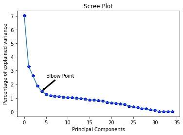

```python
# 'bp' represents blue color and pentagonal shape of points
plt.plot(eig_val,'bp')

# plot a line plot
plt.plot(eig_val)

# label the x-axis
plt.xlabel('Principal Components')

# label the y-axis
plt.ylabel('Percentage of explained variance')

# use 'annonate' function to draw an arrow between points xy and xytext
# 's' is a argument to write text
# we can change the facecolor and arrowstyle; this is only for representation purpose
plt.annotate(text ='Elbow Point', xy=(4,1.5), xytext=(5, 2.5), arrowprops=dict(facecolor='black', arrowstyle = 'simple'))

# title of the plot
plt.title('Scree Plot')

plt.show()
```

[output not shown]

### 4.6 Calculate Principal Components

```python
eigenvector = eig_vec[:,0:5]

eigenvector
```

```
array([[-0.15734148, -0.0814686 ,  0.22587062,  0.10722212, -0.00752845],
       [-0.10597576, -0.04682612,  0.26517756, -0.01500761, -0.00786312],
       [-0.25598505,  0.25193829, -0.22644764, -0.03246855,  0.04820808],
       [-0.23277906,  0.15445072, -0.2753199 , -0.01428159,  0.26832427],
       [-0.1912835 , -0.00691731,  0.04663417, -0.02642127, -0.07848375],
       [-0.14599174,  0.21408979,  0.34881371, -0.2640932 ,  0.14572962],
       [ 0.00973451,  0.03635902,  0.17643327, -0.08698812, -0.03447938],
       [-0.10716365, -0.12447427, -0.17122358,  0.56562785, -0.04965918],
       [-0.25613609,  0.11057602,  0.25506258,  0.26315384,  0.08881146],
       [-0.25253012,  0.03831097,  0.30414927,  0.28994057,  0.09159884],
       [-0.12387082, -0.38214632, -0.18281738, -0.33480834, -0.02535135],
       [ 0.02405102, -0.14573334,  0.06296919,  0.03670041,  0.18515617],
       [-0.28645931, -0.30275762,  0.07771394, -0.06143218,  0.06346053],
       [-0.08222127,  0.23681672,  0.28979777, -0.28738891,  0.21119068],
       [ 0.00858439, -0.00471851,  0.04312103, -0.04234185, -0.11468022],
       [-0.2590985 , -0.13874686, -0.14049036,  0.0834809 ,  0.15246878],
       [-0.12665322, -0.16777286, -0.18518577, -0.40155483, -0.10217345],
       [-0.10198228, -0.38862065,  0.01122215, -0.01765954,  0.0675895 ],
       [ 0.02477659, -0.18242983,  0.04827735,  0.12265694,  0.20341807],
       [-0.22719516, -0.36690744,  0.03125338, -0.01331827,  0.09111303],
       [-0.17925338, -0.06901932,  0.19246494, -0.09390436, -0.12730308],
       [-0.15040881,  0.09155029, -0.01928724, -0.03807494, -0.56606944],
       [-0.29356932,  0.0630344 , -0.04501941,  0.03321251, -0.33115807],
       [-0.28656797,  0.07257837,  0.02766991,  0.04467316, -0.31271792],
       [-0.13762475,  0.04933351,  0.05884225, -0.12311454,  0.08001895],
       [-0.14605669, -0.05274852, -0.0198202 , -0.03831603,  0.08039055],
       [ 0.08753259, -0.15254462,  0.13007553,  0.06074706, -0.04267263],
       [-0.01905378,  0.02616779, -0.00066212,  0.05503394, -0.00734891],
       [-0.02868622, -0.04202624,  0.10976166, -0.06826703, -0.18150387],
       [-0.04809051, -0.04887335,  0.14877925, -0.06046919,  0.07998556],
       [ 0.00997078, -0.02733478,  0.01981117, -0.02244414,  0.04027825],
       [-0.02004068, -0.02899349, -0.01806787,  0.04144468, -0.06368279],
       [ 0.01054073,  0.03814649,  0.00552812, -0.0435918 ,  0.12413176],
       [ 0.25598505, -0.25193829,  0.22644764,  0.03246855, -0.04820808],
       [ 0.23277906, -0.15445072,  0.2753199 ,  0.01428159, -0.26832427]])
```

**Generate a new dataset of reduced dimensions by multiplying standardize data and set of eigenvectors**

```python
# take the dot product of 'df_num_std' with 'eigenvector' to obtain new dataset
# create a dataframe of principal components
df_pca = pd.DataFrame(df_num_std.dot(eigenvector), columns= ['PC1','PC2','PC3','PC4','PC5'])

# head() to display top five rows
df_pca.head()
```

|  | PC1 | PC2 | PC3 | PC4 | PC5 |
| --- | --- | --- | --- | --- | --- |
| 0 | -1.571468 | 0.233699 | -1.586585 | -2.219473 | 0.715615 |
| 1 | -0.199890 | 0.835867 | 1.050234 | 0.097077 | -0.627275 |
| 2 | -1.740971 | 0.251788 | -1.391157 | -1.637273 | 0.046151 |
| 3 | 1.470652 | -1.877190 | 1.515307 | -0.180157 | -1.837106 |
| 4 | -4.216754 | -1.116376 | -0.533713 | -1.621483 | -0.334647 |

```python
# checking shape of new data
df_pca.shape
```

```
(1460, 5)
```

|  | **In the above output, we obtained the data with reduced dimensions. The new dataset has 1460 observations and 5 columns, i.e. we have decreased the number of numerical features from 35 to 5** |
| --- | --- |

**Now, we will use the in-built python function from sci-kit learn library to compute principal components**

## 5. PCA using sklearn

|  | **Use the in-built PCA function from the sklearn library to perform PCA and check the results with the obtained data with reduced dimensions (using scratch method)** |
| --- | --- |

```python
# specify required no of components
# take 'n_components=5' based on the analysis of scree plot
pca = PCA(n_components=5, random_state=0)

# fit_transform() computes the principal components
# pass the standardized data to fit PCA
PrincipalComponents = pca.fit_transform(df_num_std)
```

```python
# create a dataframe of principal components
PCA_df = pd.DataFrame(data = PrincipalComponents, columns = ['PC1', 'PC2','PC3','PC4','PC5'])

# head() to display top five rows
PCA_df.head()
```

|  | PC1 | PC2 | PC3 | PC4 | PC5 |
| --- | --- | --- | --- | --- | --- |
| 0 | 1.571352 | -0.240622 | -1.586777 | -2.241474 | 0.753565 |
| 1 | 0.199709 | -0.835527 | 1.042285 | 0.089567 | -0.634687 |
| 2 | 1.741028 | -0.250540 | -1.389540 | -1.627933 | 0.038217 |
| 3 | -1.470503 | 1.871470 | 1.526313 | -0.195221 | -1.759654 |
| 4 | 4.216874 | 1.125024 | -0.532845 | -1.588267 | -0.391245 |

**Here, we have used the in-built PCA function to perform dimension reduction and obtained the new dataset with 5 dimensions**

[figure not shown]